# Plant material innovation at Land Grant Universities

Intellectural property protections and matieral licensing, 1980-2020

Liza Wood, Adam Vera, Victoria Fletcher

2022-10-30

This page summarizes plant breeding activities at US Land Grant Universities (LGUs) and the subsequent trends in technology transfer between universities and companies. Data for these summaries are combined across four sources:  
1. PVP database  
2. USPTO database  
3. Licensing metadata from 25 LGUs, collected via FOIA requests  
4. Company data collected from the D&B Hoovers database

### How have LGUs been protecting their plant material?

The PVP and USPTO databases were scraped and automated text matching was used to identify applications by the 50 1862 LGUs. For PVPs, this meant looking for applications with Universities as Applicants, and for USPTO, this meant looking for LGUs as Assignees, as well as Agricultural Research Centers and State applications that were observed in the licensing agreements (see below).

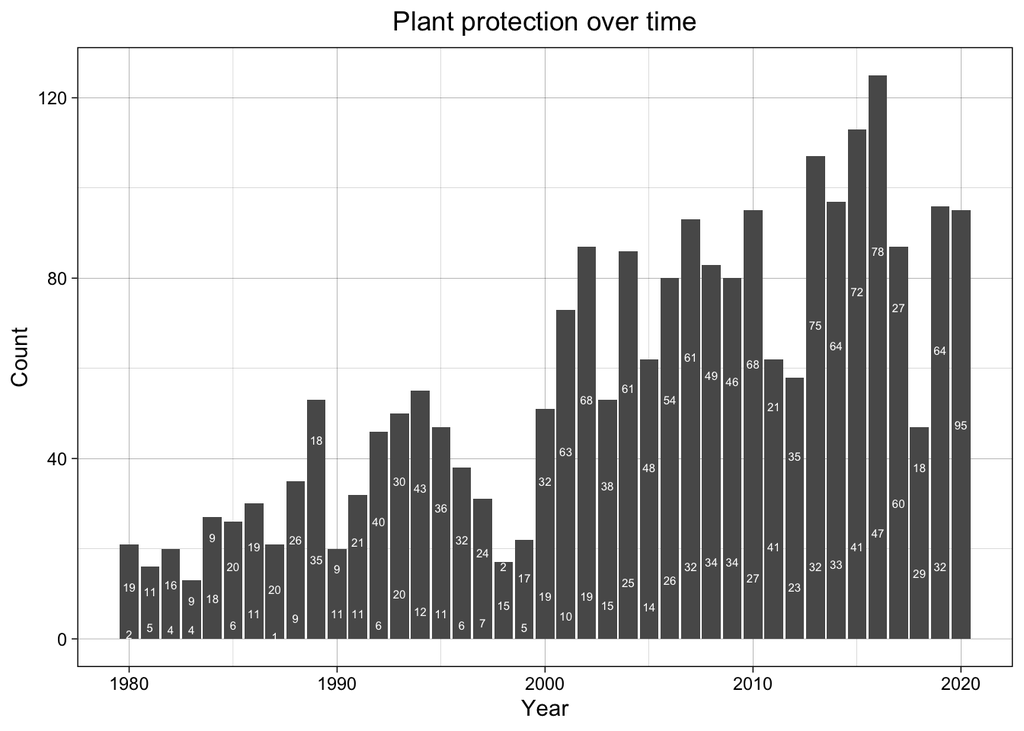